# CS685_Coding_2_Teeranat_Yingpunyachok

```python
import matplotlib.pyplot as plt
from sklearn.datasets import load_wine
import numpy as np
# Load the Wine dataset
wine = load_wine()

data = wine.data
targets = wine.target
feature_names = wine.feature_names
class_names = wine.target_names
```

Q1 Histogram

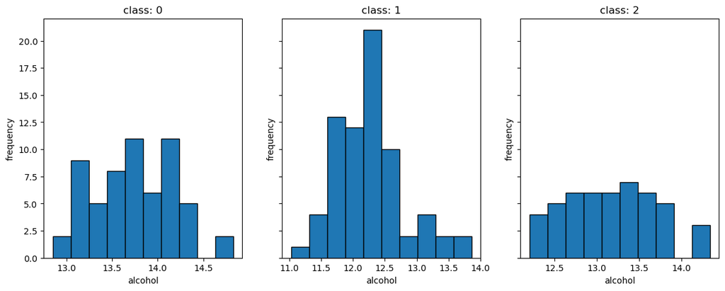

```python
# Task 1. Histogram on alcoho content

# Extract the 'alcohol' feature
alcohol_content_index = feature_names.index('alcohol')
alcohol_content = data[:, alcohol_content_index]
# TODO: Implement your code here
fig,ax =  plt.subplots(1,3,figsize=(14,5),sharey=True)
for class_num in range(3):
    alcohol_content_filtered = alcohol_content[class_num==targets]
    ax[class_num].hist(alcohol_content_filtered,bins=10,edgecolor='black')
    ax[class_num].set_title(f"class: {class_num}")
    ax[class_num].set_xlabel(f"alcohol")
    ax[class_num].set_ylabel("frequency")
plt.show()
```

# Task 1 analysis

# TODO: Provide your analysis here

#### Class 0

- Range from 12.8 to 14.8
- Mean 13.74
- Median 13.75

#### Class 1

- Range from 11 to 14
- Mean 12.28
- Median 12.29

#### Summary

- Class 0: have highest mean
- Class 1: have lowest mean, most frequency alcohol are around 12.25
- Class 2: Moderate mean, all the frequency spread out

Q2 Box Plot

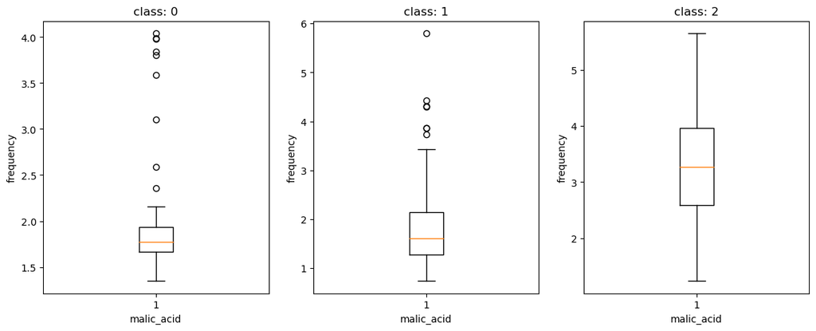

```python
# Task 2. Box plot on malic acid

# TODO: Implement your code here
fig,ax =  plt.subplots(1,3,figsize=(14,5))
malic_acid_index=  feature_names.index("malic_acid")
malic_acid =   data[:,malic_acid_index]
for class_num in range(3):
    malic_acid_filtered = malic_acid[class_num==targets]
    ax[class_num].boxplot(malic_acid_filtered,meanline=True)
    ax[class_num].set_title(f"class: {class_num}")
    ax[class_num].set_xlabel(f"malic_acid")
    ax[class_num].set_ylabel("frequency")
plt.show()
```

# Task 2 analysis

# TODO: Provide your analysis here

#### Highest Range

- class 1

#### Lowest Range

- class 0

#### Significent outliers

- class 0: many outlier compare to others two class
- class 1: there are some outliers but lower than class 0
- class 2: no outliers

Q3 Scatter Plot

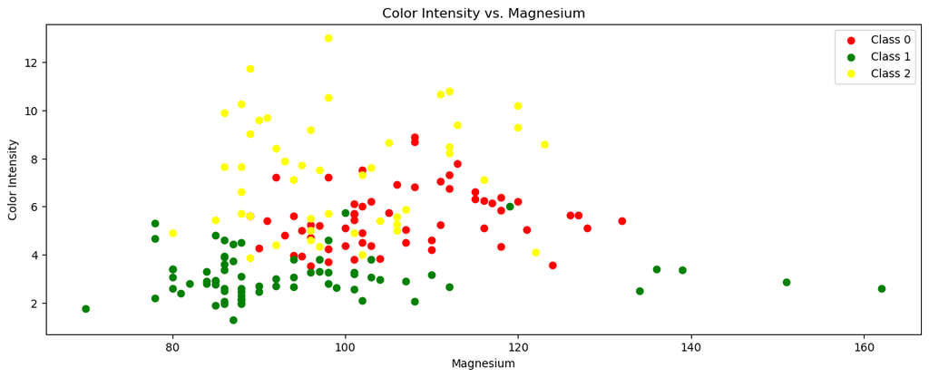

```python
# Task 3 Scatter Plot between color intensity and magnesium

# TODO: Implement your code here
color_intensity_index=  feature_names.index("color_intensity")
magnesium_index= feature_names.index("magnesium")
color_intensity = data[:,color_intensity_index]
magnesium = data[:,magnesium_index]
fig,ax =  plt.subplots(1,1,figsize=(14,5))

# color intensity vs magnesium
colors = ['red','green','yellow']
labels = ['Class 0','Class 1','Class 2']

for class_num in range(3):
    color_intensity_filtered = color_intensity[class_num==targets]
    magnesium_filtered = magnesium[class_num==targets]
    ax.scatter(magnesium_filtered, color_intensity_filtered,color=colors[class_num], label=labels[class_num])
ax.set_title("Color Intensity vs. Magnesium")
ax.set_xlabel("Magnesium")
ax.set_ylabel("Color Intensity")
ax.legend()
```

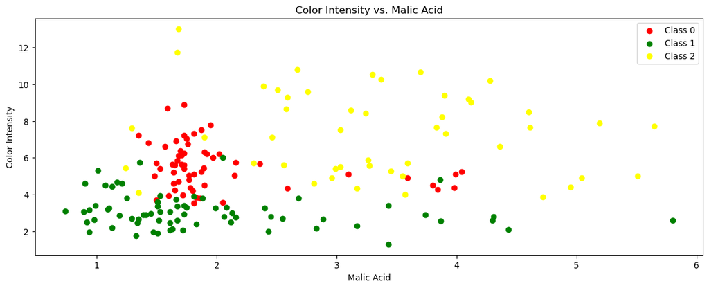

```python
# Task 3 Scatter Plot between color intensity and malic acid

# TODO: Implement your code here
fig,ax =  plt.subplots(1,1,figsize=(14,5))
# color intensity vs Malic acid
for class_num in range(3):
    color_intensity_filtered = color_intensity[class_num==targets]
    malic_acid_filtered = malic_acid[class_num==targets]
    ax.scatter(malic_acid_filtered, color_intensity_filtered,color=colors[class_num], label=labels[class_num])
ax.set_title("Color Intensity vs. Malic Acid")
ax.set_xlabel("Malic Acid")
ax.set_ylabel("Color Intensity")
ax.legend()
```

# Task 3 analysis

# TODO: Provide your analysis here

#### Color Intensity vs. Magnesium

- class 0: all clustered in between class1 , and class2
- class 1: low color intensity in every magnesium level despite some is more then 130
- class 2: higher color intensity at various magnesium levels

#### Color Intensity vs. Malic acid

Q4 Correlation Heatmap

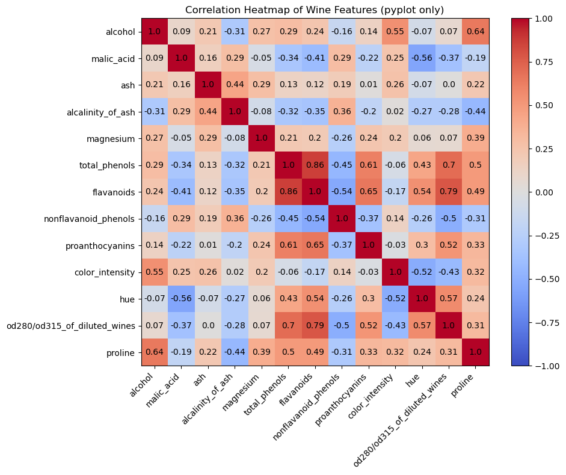

```python
# TODO: Compute Pearson correlation matrix using numpy.corrcoef
fig, ax = plt.subplots(figsize=(10, 8))
correlation_matrix = np.corrcoef(data, rowvar=False)
# TODO: Plot heatmap using ax.imshow
cs_m = ax.imshow(correlation_matrix, cmap='coolwarm', vmin=-1, vmax=1)
# TODO: Add colorbar
fig.colorbar(cs_m)
# TODO: Set X and Y labels to the feature names
ax.set_xticks(np.arange(len(feature_names)))
ax.set_yticks(np.arange(len(feature_names)))
ax.set_xticklabels(feature_names,rotation=45,ha='right')
ax.set_yticklabels(feature_names)
for i in range(len(feature_names)):
    for j in range(len(feature_names)):
        label = np.round(correlation_matrix[i,j], decimals=2)
        ax.text(j, i, label, ha='center', va='center', color='black')

ax.set_title("Correlation Heatmap of Wine Features (pyplot only)")
fig.tight_layout()
plt.show()
```

# task 3 identify

#### High positive correlation: flavanoids and total_phenols (+0.86)

#### High negative correlation: hue and malic_acid (-0.56)